# Project1 Draft

Chuwen Liu

### Introduction

The dataset provided by Urban Ministries of Durham shows the living material support for people in need, and the time span is around 90 years. There are many variables such as food pounds, clothing items and diapers. We would like to check the trend and predict the change of future support.

At first I am going to do some cleaning work, such as arrange the data row based on the Date, and remove some data rows including NA.

```r
UMD <- read_tsv("https://raw.githubusercontent.com/biodatascience/datasci611/gh-pages/data/project1_2019/UMD_Services_Provided_20190719.tsv")
UMD1 = UMD
#convert the data type
UMD1$Date <- as.Date(UMD1$Date, "%m/%d/%Y")

#clear out the extraneous variable, clear the unmeaningful date and add "year" variable
UMD1 <- UMD1%>%filter(Date <= Sys.Date())%>%select(-Referrals,-`Field1`,-`Field2`,-`Field3`)%>%arrange(Date,`Client File Number`,`Client File Merge`)%>% mutate(year = as.numeric(format(Date,"%Y")))
```

### Food supply

I would like to explore the trend of food supply, so at first we consider “Food Provided For” and “Food Pounds” two variables.

```r
UMD_food = UMD1 %>% select(Date,year,`Client File Number`,`Client File Merge`,`Food Provided for`,`Food Pounds`)%>%filter(!is.na(`Food Provided for`) & !is.na(`Food Pounds`))
table(UMD_food$year)
```

```
##
## 1931 1941 1951 1961 1971 1981 1990 1991 1999 2000 2001 2002 2003 2004 2005
##   11    5    5    2    7    7    1    8    1    4   19    3    5    2  106
## 2006 2007 2008 2009 2010 2011 2012 2013 2014 2015 2016 2017 2018 2019
## 1506 1804 2219 3164 3458 3771 3947 4048 4526 4585 4466 4339 4816 2506
```

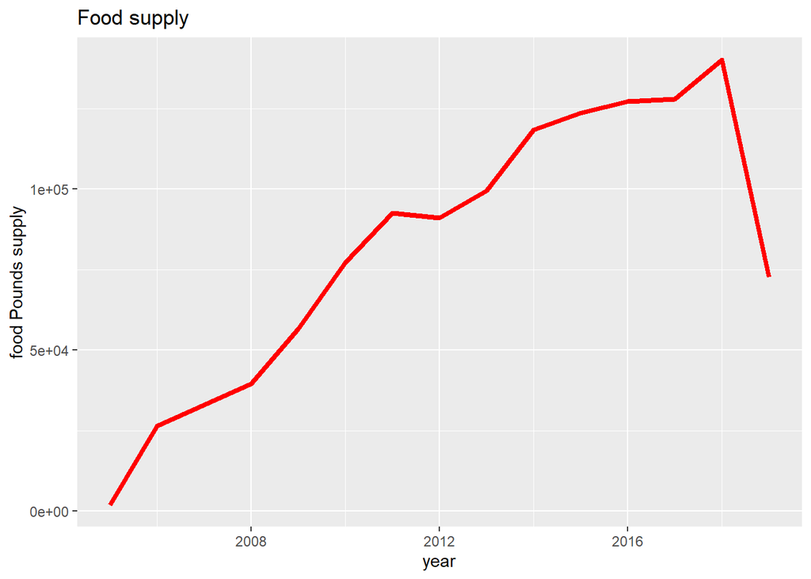

```r
# Based on the frequency, we consider the time period 2005-2019; and there's some outliers in Food Pounds, so we restrict the condition `Food Pounds` < 200
Food_pound <- UMD_food%>%filter(Date <= Sys.Date() & Date >= "2005-01-01",`Food Pounds` < 200)%>%group_by(year)%>%summarise(foodsum = sum(`Food Pounds`),peoplesum = sum(`Food Provided for`),food.ave = sum(`Food Pounds`)/sum(`Food Provided for`))

ggplot(Food_pound,aes(x= year,y=foodsum))+geom_line(size=1.5,col="red")+
  labs(x = "year",y = "food Pounds supply",title = "Food supply")+theme_bw()+theme_grey()
```

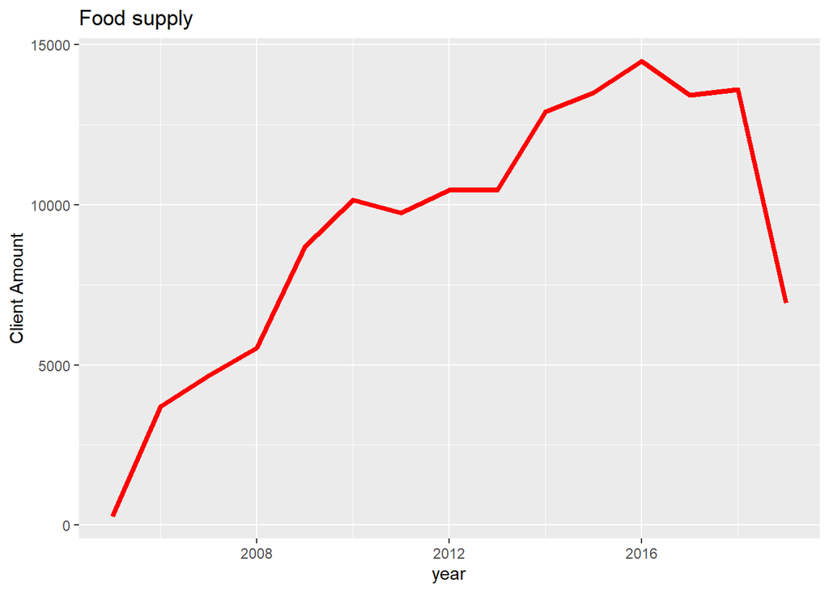

```r
ggplot(Food_pound,aes(x = year, y = peoplesum))+geom_line(size=1.5,col="red")+
  labs(x = "year",y = "Client Amount",title = "Food supply")+theme_bw()+theme_grey()
```

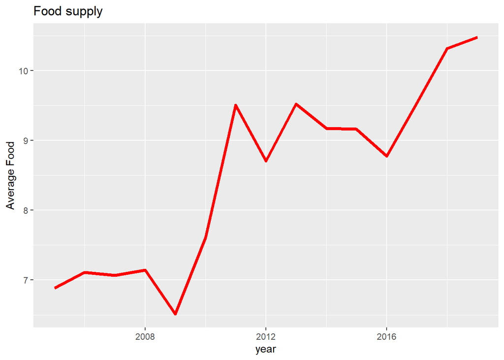

```r
ggplot(Food_pound,aes(x = year, y = food.ave))+geom_line(size=1.5,col="red")+
  labs(x = "year",y = "Average Food",title = "Food supply")+theme_bw()+theme_grey()
```

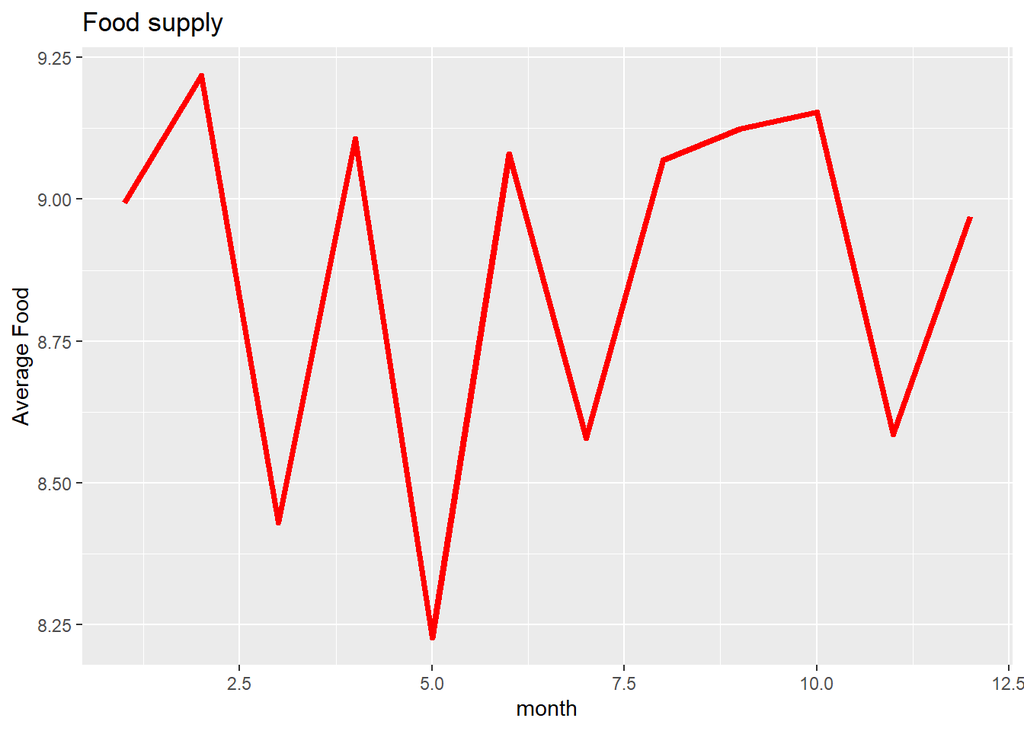

```r
#For food supply, it begins to increase from around 2005. Then we want to know if it is affected by seasons.
UMD_food$year = as.factor(UMD_food$year)
Food_pound1 <- UMD_food%>%filter(Date <= Sys.Date() & Date >= "2000-01-01",`Food Pounds` < 200)%>%mutate(month = as.integer(format(Date,"%m")))%>%
  group_by(month)%>%summarise(foodof = sum(`Food Pounds`),people = sum(`Food Provided for`),food.ave = sum(`Food Pounds`)/sum(`Food Provided for`))
ggplot(Food_pound1,aes(x = month, y = food.ave))+geom_line(size=1.5,col="red")+
  labs(x = "month",y = "Average Food",title = "Food supply")+theme_bw()+theme_grey()
```

```r
m = mean(Food_pound1$food.ave)
chis = sum((Food_pound1$food.ave-m)^2/m)
1-pchisq(chis,11)
```

```
## [1] 1
```

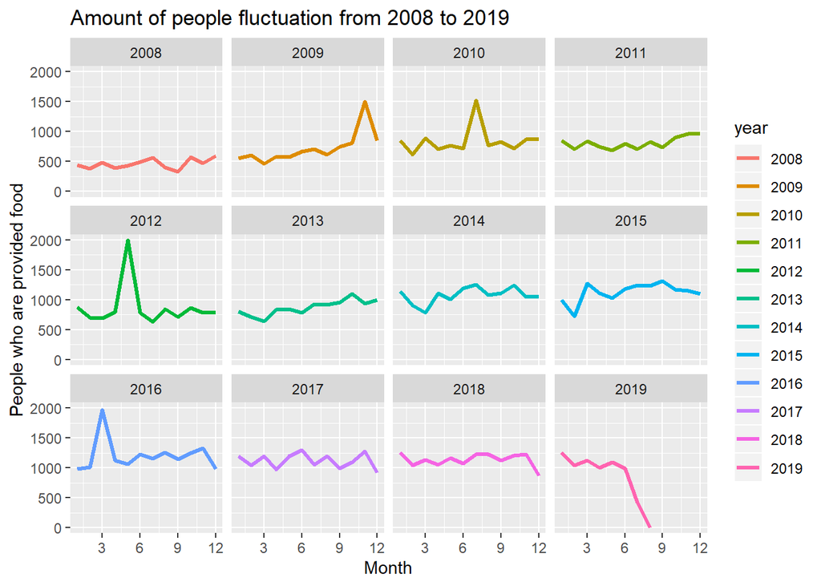

```r
#After chisq goodness of fit test, we know that the p-value is near 1, so we could not reject the null hypothesis, which means Food supply per person has no association with month change.

#Next we draw the curve divided by "year" and the x axis represents month. We observe "clients who receive food" and "total food pounds"

UMD_foodmonth <- UMD_food%>%filter(Date <= Sys.Date() & Date >= "2008-01-01",`Food Pounds` < 300)%>%mutate(month = as.integer(format(Date,"%m")))%>%
  group_by(year=as.factor(year),month)%>%summarise(foodsum = sum(`Food Pounds`),people = sum(`Food Provided for`),food.ave = sum(`Food Pounds`)/sum(`Food Provided for`))

ggplot(UMD_foodmonth,aes(x=month,y=people,col=year))+geom_line(size=1.2)+facet_wrap(~year)+scale_x_continuous(breaks = seq(0,12,3))+labs(x="Month",y="People who are provided food",title = "Amount of people fluctuation from 2008 to 2019")
```

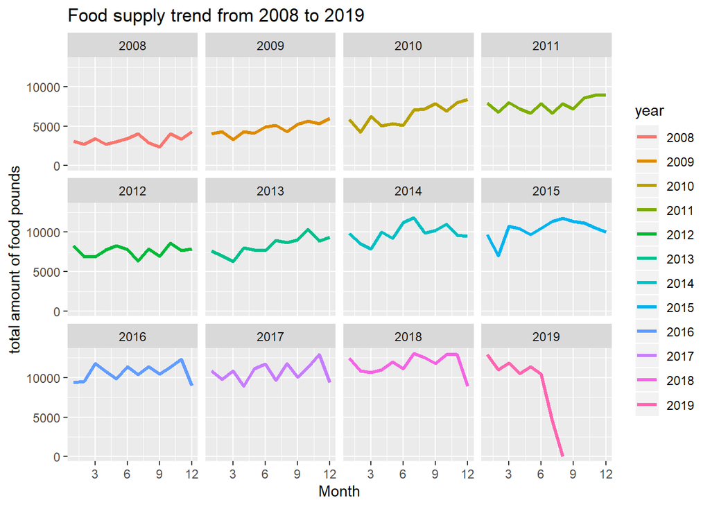

```r
ggplot(UMD_foodmonth,aes(x=month,y=foodsum,col=year))+geom_line(size=1.2)+facet_wrap(~year)+scale_x_continuous(breaks = seq(0,12,3))+labs(x="Month",y="total amount of food pounds",title = "Food supply trend from 2008 to 2019")
```

I will also try to connect the food demand and clothing item in my final project. Sometimes people need more food and clothing item at the same time due to the population growth in their family, but when conisdering the seasons and temprature, it will be more complex.

```r
UMD_foodcloth <- UMD1 %>% select(Date,year,`Client File Number`,`Food Provided for`,`Food Pounds`,`Clothing Items`)%>%drop_na(`Food Provided for`,`Food Pounds`,`Clothing Items`) %>% filter(`Food Pounds` < 300)%>% group_by(`Client File Number`,year)%>% summarise(food.id = mean(`Food Pounds`),cloth.id = mean(`Clothing Items`))

mod = lm(food.id~cloth.id,data=UMD_foodcloth)
summary(mod)
```

```
##
## Call:
## lm(formula = food.id ~ cloth.id, data = UMD_foodcloth)
##
## Residuals:
##     Min      1Q  Median      3Q     Max
## -70.433  -6.918  -2.693   4.592 181.571
##
## Coefficients:
##             Estimate Std. Error t value Pr(>|t|)
## (Intercept) 16.68376    0.13720  121.60   <2e-16 ***
## cloth.id     0.87239    0.01252   69.69   <2e-16 ***
## ---
## Signif. codes:  0 '***' 0.001 '**' 0.01 '*' 0.05 '.' 0.1 ' ' 1
##
## Residual standard error: 11.09 on 18648 degrees of freedom
## Multiple R-squared:  0.2066, Adjusted R-squared:  0.2066
## F-statistic:  4857 on 1 and 18648 DF,  p-value: < 2.2e-16
```

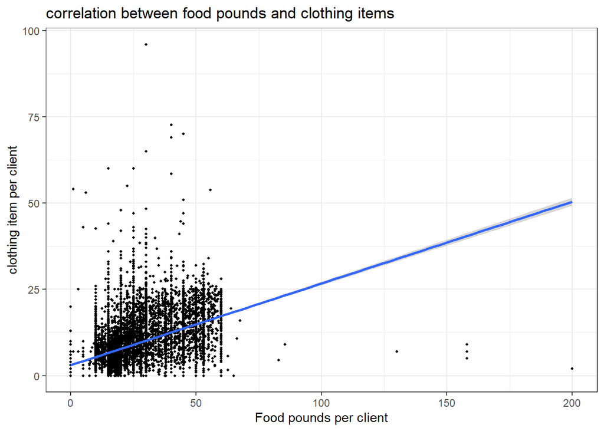

```r
ggplot(UMD_foodcloth,aes(x=food.id,y=cloth.id))+geom_point(size = .7)+geom_smooth(method = "lm")+labs(x="Food pounds per client",y="clothing item per client",title = "correlation between food pounds and clothing items")+theme_bw()
```

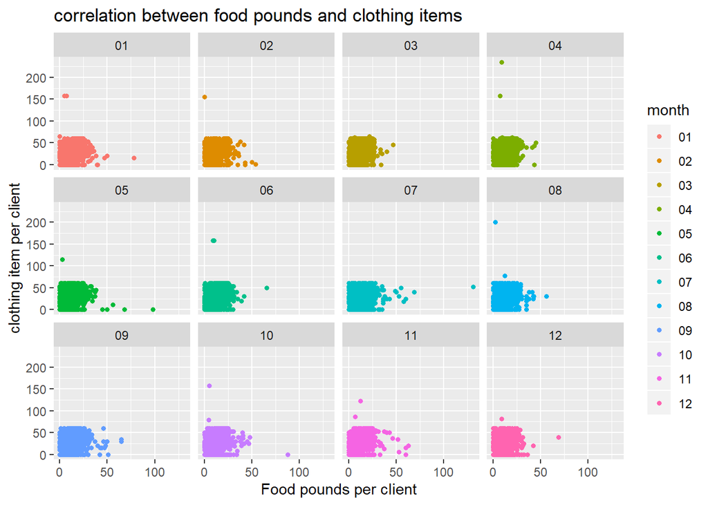

```r
# We can see that p-value of linear model is very low, so there's linear correlation between clothing items and food pounds per client. But the R-squared statistics is not very high. And the demand for food might increase more rapidly than demand of clothing.

UMD_foodcloth1 <- UMD1 %>% select(Date,`Client File Number`,`Food Pounds`,`Clothing Items`)%>%drop_na(`Food Pounds`,`Clothing Items`) %>% filter(`Food Pounds` < 300)%>% mutate(month = as.factor(format(Date,"%m")))%>%group_by(`Client File Number`,month)%>% summarise(food.id = mean(`Food Pounds`),cloth.id = mean(`Clothing Items`))

ggplot(UMD_foodcloth1,aes(x=cloth.id,y=food.id,col=month))+geom_point(size=1.2)+facet_wrap(~month)+labs(x="Food pounds per client",y="clothing item per client",title = "correlation between food pounds and clothing items")
```

```r
# From the plot month seems have little effect on deciding the correlation between food supply and clothing items
```

### Clothing items, school kits and Diapers: Will they have some correlation?

Next we are going to figure out the trend of clothing item and diapers, we want to know if there’s some link between the demand and seasons.

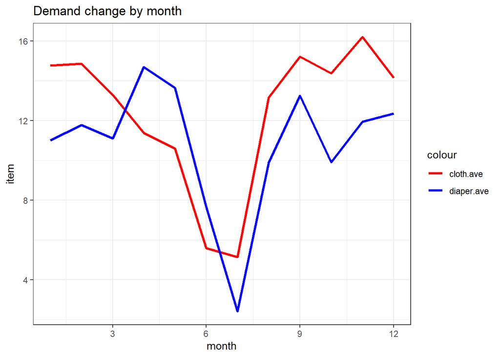

```r
UMD_cloth <- UMD1 %>% select(Date,year,`Client File Number`,`Client File Merge`,`Clothing Items`,Diapers)%>% drop_na(`Clothing Items`,Diapers)

tmp<-UMD_cloth %>% mutate(month = as.numeric(format(Date,"%m"))) %>%
  filter(Diapers < 500)%>% group_by(month) %>%
  summarise(count =n(),cloth.ave = mean(`Clothing Items`),diaper.ave = mean(Diapers))

ggplot(tmp)+geom_line(aes(x=month,y=cloth.ave,col="cloth.ave"),size = 1.2)+
  geom_line(aes(x=month,y=diaper.ave,col="diaper.ave"),size = 1.2)+scale_color_manual(values = c("red", "blue"))+
  labs(x="month",y="item",title = "Demand change by month")+scale_x_continuous(breaks = seq(0,12,3))+theme_bw()
```

```r
#We could find that for clothing item, it is obvious that in summer time(May to July) the demand for clothing item is decreasing, and we found that in January there is a peak for diapers need. After more observation, we found that in January, 2018 there's an unnormal amount of need for diapers, and we regard it as an outlier. So we add a condition 'Diapers < 500'.
```

I want to explore if there’s any association between diapers and school kits, since it all indicates the growth of children.

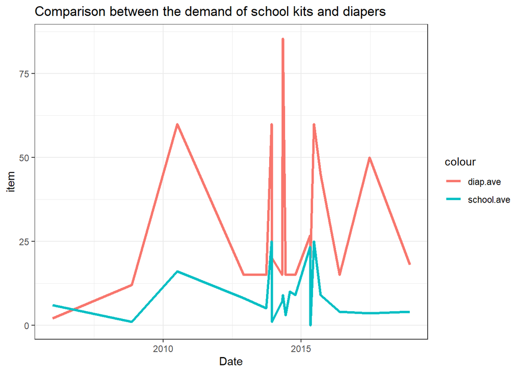

```r
UMD_kids <- UMD1 %>% select(Date,year,`Client File Number`,`Client File Merge`,`School Kits`,Diapers)%>% drop_na(`School Kits`,Diapers)

UMD_kids%>%filter(year >= 2005,Diapers < 1000)%>%group_by(Date)%>%summarise(diap.ave = mean(Diapers),school.ave = mean(`School Kits`))%>%
  ggplot()+geom_line(aes(x=Date,y=diap.ave,col="diap.ave"),size=1.2)+geom_line(aes(x=Date,y=school.ave,col="school.ave"),size=1.2)+
  labs(x="Date",y="item",title="Comparison between the demand of school kits and diapers")+theme_bw()
```

```r
# There's a correlation more than 0.5, so it is a bit correlated.
```

[output not shown]

We know from the plot that for the two items, change is similar and the Pearson correlation we calculate is not very small. Is it a causal problem? I think they should be link with a time difference, but it seems not.